# Project - Unsupervised Learning - AllLife Bank Customer Segmentation

## Background and Context

AllLife Bank wants to focus on its credit card customer base in the next financial year. They have been advised by their marketing research team, that the penetration in the market can be improved. Based on this input, the Marketing team proposes to run personalized campaigns to target new customers as well as upsell to existing customers. Another insight from the market research was that the customers perceive the support services of the bank poorly. Based on this, the Operations team wants to upgrade the service delivery model, to ensure that customer queries are resolved faster. Head of Marketing and Head of Delivery both decide to reach out to the Data Science team for help.

The data provided is of various customers of a bank and their financial attributes like credit limit, the total number of credit cards the customer has, and different channels through which customers have contacted the bank for any queries (including visiting the bank, online and through a call center).

## Objective

To identify different segments in the existing customer, based on their spending patterns as well as past interaction with the bank, using clustering algorithms, and provide recommendations to the bank on how to better market and service these customers.

## Key Questions

1. How customers can be segmented to run personalized campaigns to target new customers?
2. Which segment of customers can be targetted for upselling new products?
3. Which group of customers perceive the support services of the bank poorly and how to improve the service delivery model?

## Data Dictionary

- Sl_No: Primary key of the records
- Customer Key: Customer identification number
- Average Credit Limit: Average credit limit of each customer for all credit cards
- Total credit cards: Total number of credit cards possessed by the customer
- Total visits bank: Total number of visits that customer made (yearly) personally to the bank
- Total visits online: Total number of visits or online logins made by the customer (yearly)
- Total calls made: Total number of calls made by the customer to the bank or its customer service department (yearly)

```python
# Library to suppress warnings or deprecation notes
import warnings
warnings.filterwarnings('ignore')

# Libraries to help with reading and manipulating data
import pandas as pd
import numpy as np

# Libraries to help with data visualization
import matplotlib.pyplot as plt
import seaborn as sns
%matplotlib inline

from scipy.stats import zscore

# Removes the limit from the number of displayed columns and rows.
# This is so that we can see the entire dataframe when we print it
pd.set_option('display.max_columns', None)
# pd.set_option('display.max_rows', None)
pd.set_option('display.max_rows', 200)
# We are setting the random seed via np.random.seed so that
# we get the same random results every time
np.random.seed(1)
```

```python
# Read the dataset
data = pd.read_excel('Credit+Card+Customer+Data.xlsx')
```

```python
print(f'Number of rows: {data.shape[0]} and number of columns: {data.shape[1]}')
```

```
Number of rows: 660 and number of columns: 7
```

```python
# Check the first 5 rows of data
data.head()
```

|  | Sl_No | Customer Key | Avg_Credit_Limit | Total_Credit_Cards | Total_visits_bank | Total_visits_online | Total_calls_made |
| --- | --- | --- | --- | --- | --- | --- | --- |
| 0 | 1 | 87073 | 100000 | 2 | 1 | 1 | 0 |
| 1 | 2 | 38414 | 50000 | 3 | 0 | 10 | 9 |
| 2 | 3 | 17341 | 50000 | 7 | 1 | 3 | 4 |
| 3 | 4 | 40496 | 30000 | 5 | 1 | 1 | 4 |
| 4 | 5 | 47437 | 100000 | 6 | 0 | 12 | 3 |

```python
# Check the last 5 rows of data
data.tail()
```

|  | Sl_No | Customer Key | Avg_Credit_Limit | Total_Credit_Cards | Total_visits_bank | Total_visits_online | Total_calls_made |
| --- | --- | --- | --- | --- | --- | --- | --- |
| 655 | 656 | 51108 | 99000 | 10 | 1 | 10 | 0 |
| 656 | 657 | 60732 | 84000 | 10 | 1 | 13 | 2 |
| 657 | 658 | 53834 | 145000 | 8 | 1 | 9 | 1 |
| 658 | 659 | 80655 | 172000 | 10 | 1 | 15 | 0 |
| 659 | 660 | 80150 | 167000 | 9 | 0 | 12 | 2 |

```python
# checking column names, datatypes and number of non-null values
data.info()
```

```
<class 'pandas.core.frame.DataFrame'>
RangeIndex: 660 entries, 0 to 659
Data columns (total 7 columns):
 #   Column               Non-Null Count  Dtype
---  ------               --------------  -----
 0   Sl_No                660 non-null    int64
 1   Customer Key         660 non-null    int64
 2   Avg_Credit_Limit     660 non-null    int64
 3   Total_Credit_Cards   660 non-null    int64
 4   Total_visits_bank    660 non-null    int64
 5   Total_visits_online  660 non-null    int64
 6   Total_calls_made     660 non-null    int64
dtypes: int64(7)
memory usage: 36.2 KB
```

> **Observations:**
> - Sl_No column can be dropped as it is a sequence number and does not contain any useful information.
> - Customer Key seems to be unique numbers and does not contain any useful information for this analysis.
> - There are no null values in any of the columns.
> - All columns are of numeric type.

```python
# Check number of duplicate records in the dataset
data.duplicated().sum()
```

```
0
```

```python
data.isnull().sum()
```

```
Sl_No                  0
Customer Key           0
Avg_Credit_Limit       0
Total_Credit_Cards     0
Total_visits_bank      0
Total_visits_online    0
Total_calls_made       0
dtype: int64
```

```python
# Take a copy of the data, do not modify the original data as we will need this later
data_bkp = data.copy()
```

```python
data.drop(['Sl_No'], axis=1, inplace=True)
```

```python
# Check if the Customer Key contains duplicate values
data[data['Customer Key'].duplicated(keep=False) == True].sort_values(by='Customer Key')
```

|  | Customer Key | Avg_Credit_Limit | Total_Credit_Cards | Total_visits_bank | Total_visits_online | Total_calls_made |
| --- | --- | --- | --- | --- | --- | --- |
| 48 | 37252 | 6000 | 4 | 0 | 2 | 8 |
| 432 | 37252 | 59000 | 6 | 2 | 1 | 2 |
| 4 | 47437 | 100000 | 6 | 0 | 12 | 3 |
| 332 | 47437 | 17000 | 7 | 3 | 1 | 0 |
| 411 | 50706 | 44000 | 4 | 5 | 0 | 2 |
| 541 | 50706 | 60000 | 7 | 5 | 2 | 2 |
| 391 | 96929 | 13000 | 4 | 5 | 0 | 0 |
| 398 | 96929 | 67000 | 6 | 2 | 2 | 2 |
| 104 | 97935 | 17000 | 2 | 1 | 2 | 10 |
| 632 | 97935 | 187000 | 7 | 1 | 7 | 0 |

The duplicate values might correspond to customer profile changes, and as such, there is no need to delete these records as these are actual occurrences at some point in the time. The Customer Key column can be dropped during the analysis.

```python
data.drop(['Customer Key'], axis=1, inplace=True)
```

```python
# Check the Summary of the data for numerical columns
data.describe().T
```

|  | count | mean | std | min | 25% | 50% | 75% | max |
| --- | --- | --- | --- | --- | --- | --- | --- | --- |
| Avg_Credit_Limit | 660.0 | 34574.242424 | 37625.487804 | 3000.0 | 10000.0 | 18000.0 | 48000.0 | 200000.0 |
| Total_Credit_Cards | 660.0 | 4.706061 | 2.167835 | 1.0 | 3.0 | 5.0 | 6.0 | 10.0 |
| Total_visits_bank | 660.0 | 2.403030 | 1.631813 | 0.0 | 1.0 | 2.0 | 4.0 | 5.0 |
| Total_visits_online | 660.0 | 2.606061 | 2.935724 | 0.0 | 1.0 | 2.0 | 4.0 | 15.0 |
| Total_calls_made | 660.0 | 3.583333 | 2.865317 | 0.0 | 1.0 | 3.0 | 5.0 | 10.0 |

> **Observations:**
> - Avg_Credit_Limit: Ranges from 3K to 200K with a mean around 34.5K and median of 18K.
> - Total_Credit_Cards: Customers are having 1 to 10 credit cards, average number of credit cards per customers is 4 to 5.
> - Total_visits_bank: Yearly max visit to bank is 5. There are customers who did not visit the bank at all in a year.
> - Total_visits_online: There are customers who have not used online banking but on an average customers have used online baking 2 to 3 times a year.
> - Total_calls_made: There are customers who had to call bank 10 times a year! On an average customers have called bank helpline 3 to 4 times a year.

## Univariate analysis

Let's check the distribution of each feature and comment on the feature distribution as necessary. For this purpose we define the below functions to analyze the nemerical and categorical type of values effectively.

```python
# function to plot a boxplot and a histogram along the same scale.
def box_hist_plot(data, feature, figsize=(12, 7), bins=20):
    """
    This will show a box and hist plot in a column alignment, For hist plot kde is set to True

    data: dataframe
    feature: dataframe column
    figsize: size of figure (default (12,7))
    """
    # creating the 2 subplots
    f2, (ax_box2, ax_hist2) = plt.subplots(
        nrows=2,  # Number of rows of the subplot grid= 2
        sharex=True,  # x-axis will be shared among all subplots
        gridspec_kw={"height_ratios": (0.25, 0.75)},
        figsize=figsize,
    )
    # boxplot will be created and a star will indicate the mean value of the column
    sns.boxplot(data=data, x=feature, ax=ax_box2, showmeans=True, color="violet")
    # For hist plot
    sns.histplot(data=data, x=feature, kde=True, bins=bins, ax=ax_hist2)
    # Add mean to the histogram
    ax_hist2.axvline(data[feature].mean(), color="green", linestyle="--")
    # Add median to the histogram
    ax_hist2.axvline(data[feature].median(), color="black", linestyle="-")
```

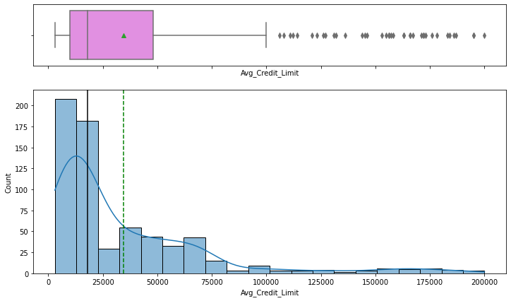

```python
box_hist_plot(data, 'Avg_Credit_Limit')
```

> **Observations:**
> - Avg_Credit_Limit ranges from 3K to 200K and median is left of the mean.
> - The distribution is highly right skewed with many outliers.

Lets check the data points where we have high credit limit e.g. greater than 150K.

```python
data[data['Avg_Credit_Limit'] > 150000].sort_values(by='Avg_Credit_Limit', ascending=False)
```

|  | Avg_Credit_Limit | Total_Credit_Cards | Total_visits_bank | Total_visits_online | Total_calls_made |
| --- | --- | --- | --- | --- | --- |
| 630 | 200000 | 10 | 0 | 13 | 0 |
| 650 | 195000 | 10 | 1 | 12 | 2 |
| 631 | 195000 | 8 | 0 | 15 | 0 |
| 632 | 187000 | 7 | 1 | 7 | 0 |
| 646 | 186000 | 7 | 0 | 8 | 1 |
| 639 | 184000 | 7 | 1 | 15 | 2 |
| 647 | 183000 | 9 | 0 | 9 | 2 |
| 624 | 178000 | 7 | 0 | 11 | 0 |
| 622 | 176000 | 10 | 1 | 15 | 2 |
| 637 | 173000 | 9 | 1 | 11 | 0 |
| 658 | 172000 | 10 | 1 | 15 | 0 |
| 654 | 172000 | 10 | 1 | 9 | 1 |
| 645 | 171000 | 10 | 0 | 15 | 0 |
| 659 | 167000 | 9 | 0 | 12 | 2 |
| 621 | 166000 | 9 | 1 | 12 | 2 |
| 623 | 166000 | 10 | 0 | 7 | 0 |
| 633 | 163000 | 7 | 1 | 10 | 1 |
| 614 | 163000 | 8 | 1 | 7 | 1 |
| 619 | 158000 | 7 | 0 | 13 | 0 |
| 612 | 157000 | 9 | 1 | 14 | 1 |
| 652 | 156000 | 8 | 1 | 8 | 0 |
| 626 | 156000 | 9 | 1 | 10 | 2 |
| 629 | 155000 | 8 | 0 | 7 | 2 |
| 638 | 153000 | 8 | 1 | 7 | 1 |

We notice that for high credit limit customers the number of credit cards are 7 or more. So high credit limit for these customers are justified and we cannot treat them as outliers.

For all other columns we will use bar plots to visualize the data better.

```python
# function to create bar plot with percent labels
def bar_perc_plot(data, feature):
    """
    Barplot with percentage at the top

    data: dataframe
    feature: dataframe column
    """

    # calculate the fig width dynamically
    total = len(data[feature])
    count = data[feature].nunique()
    plt.figure(figsize=(count + 1, 5))

    plt.xticks(rotation=90, fontsize=15)
    ax = sns.countplot(
        data=data,
        x=feature,
        palette="Paired",
        # Sort the bars from high to low
        order=data[feature].value_counts().sort_values(ascending=False).index,
    )

    for bar in ax.patches:
        # percentage of each class of the category
        label = "{:.2f}%".format(100 * bar.get_height() / total)
        x = bar.get_x() + bar.get_width() / 2  # width of the plot
        y = bar.get_height()  # height of the plot

        # annotate the percentage
        ax.annotate(
            label,
            (x, y),
            ha="center",
            va="center",
            size=12,
            xytext=(0, 5),
            textcoords="offset points",
        )

    plt.show();  # show the plot
```

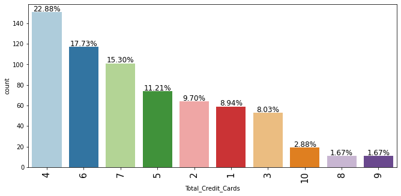

```python
bar_perc_plot(data, 'Total_Credit_Cards')
```

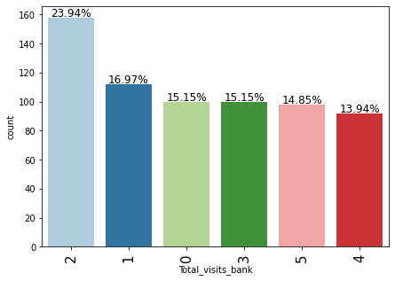

```python
bar_perc_plot(data, 'Total_visits_bank')
```

> **Observations:**
> - About 15% of customers have never visited the bank in a year.
> - Around 45% customers had to visit the bank 3 to 5 times in a year.
> - Customers who visited the bank in a year just one or 2 times are around 40%.

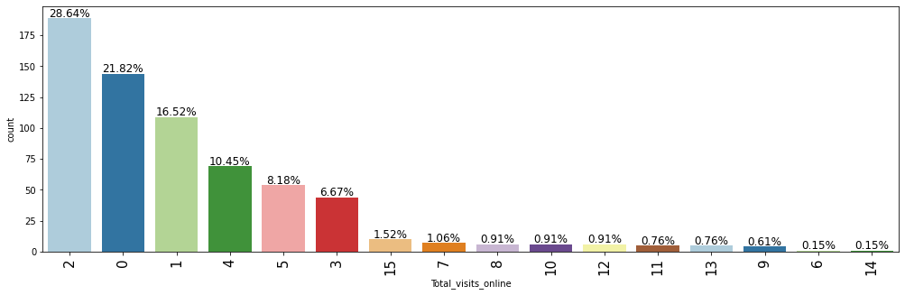

```python
bar_perc_plot(data, 'Total_visits_online')
```

> **Observations:**
> - Significant percentage of customers (around 22%) have never used online banking in a year.
> - Majority of customers have used online banking from 1 to 5 times in a year.
> - Customers who used online banking for more than 5 times a year are very less.

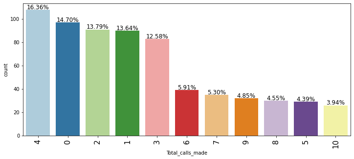

```python
bar_perc_plot(data, 'Total_calls_made')
```

> **Observations:**
> - About 15% customers had no need to call the bank in a year.
> - Around 30% of customers had to call bank more than 4 times a year to upto 10 times.
> - Rest of the customers reached out to bank using phone one to 4 times a year.

## Bivariate analysis

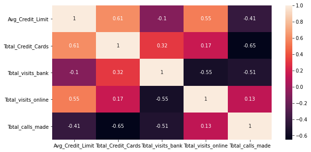

```python
# Check the correlation between features
plt.figure(figsize=(10,5))
sns.heatmap(data.corr(), annot=True);
```

> **Observations:**
> - Avg Credit limit and credit cards have a high positive correlation of 0.61. But it is not strong enough to exclude one of the feature from the analysis.
> - Total calls made have negative correlation with Avg credit limit, total credit cards and total visit to banks. This explains that, customers who have higher avg credit limit and cards or who prefer to go to bank, do not prefer to call the bank.
> - Total visit to online and total visit to bank are negatively correlated which also makes sense. Customers who prefer online will less likely to go to bank.
> - Interesting to note that, total visit online has a positive correlation with avg credit limit. Which means customers who have higher credit limit tends to go online for servicing.
> - Other features are not so much correlated with each other.

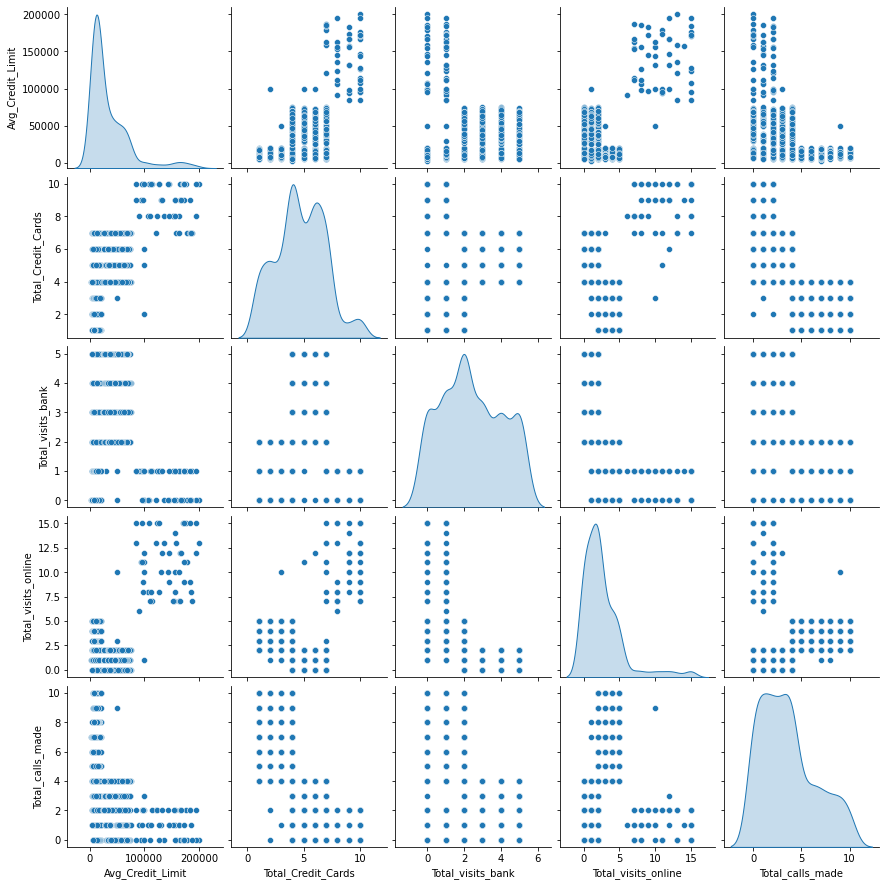

```python
# Checking the pairplot of all the relations
sns.pairplot(data, diag_kind="kde");
```

## Data Preprocessing

```python
# scaling the dataset before clustering
dataScaled=data.apply(zscore)
```

```python
dataScaled.describe().T
```

|  | count | mean | std | min | 25% | 50% | 75% | max |
| --- | --- | --- | --- | --- | --- | --- | --- | --- |
| Avg_Credit_Limit | 660.0 | 8.195465e-16 | 1.000758 | -0.839808 | -0.653623 | -0.440840 | 0.357097 | 4.399975 |
| Total_Credit_Cards | 660.0 | -4.006223e-15 | 1.000758 | -1.710864 | -0.787585 | 0.135694 | 0.597334 | 2.443892 |
| Total_visits_bank | 660.0 | 1.157323e-16 | 1.000758 | -1.473731 | -0.860451 | -0.247170 | 0.979390 | 1.592670 |
| Total_visits_online | 660.0 | 1.944572e-16 | 1.000758 | -0.888380 | -0.547490 | -0.206600 | 0.475180 | 4.224968 |
| Total_calls_made | 660.0 | -7.112156e-16 | 1.000758 | -1.251537 | -0.902271 | -0.203739 | 0.494794 | 2.241125 |

After applying Z-Score we see that mean is close to zero and standard deviation is close to 1.

## K-means Clustering

We will apply K-means clustering on the scaled data to figure out the appropriate number of segments or clusters and visualize them.

```python
from sklearn.cluster import KMeans

# to compute distances
from scipy.spatial.distance import cdist
from sklearn.metrics import silhouette_score

# to visualize the elbow curve and silhouette scores
#!pip install yellowbrick
from yellowbrick.cluster import KElbowVisualizer, SilhouetteVisualizer
```

```
Number of Clusters: 1 	Average Distortion: 2.0069222262503614
Number of Clusters: 2 	Average Distortion: 1.4571553548514269
Number of Clusters: 3 	Average Distortion: 1.1466276549150365
Number of Clusters: 4 	Average Distortion: 1.0463825294774465
Number of Clusters: 5 	Average Distortion: 0.9908683849620168
Number of Clusters: 6 	Average Distortion: 0.9431306087808111
Number of Clusters: 7 	Average Distortion: 0.9228219141364191
Number of Clusters: 8 	Average Distortion: 0.8912155076516123
```

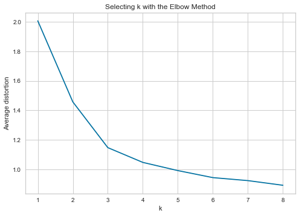

```
CPU times: user 1.04 s, sys: 54.7 ms, total: 1.09 s
Wall time: 380 ms
```

```python
%%time
clusters = range(1, 9)
meanDistortions = []

for k in clusters:
    model = KMeans(n_clusters=k)
    model.fit(dataScaled)
    prediction = model.predict(dataScaled)
    distortion = (
        sum(
            np.min(cdist(dataScaled, model.cluster_centers_, "euclidean"), axis=1)
        )
        / dataScaled.shape[0]
    )

    meanDistortions.append(distortion)

    print("Number of Clusters:", k, "\tAverage Distortion:", distortion)

plt.plot(clusters, meanDistortions, "bx-")
plt.xlabel("k")
plt.ylabel("Average distortion")
plt.title("Selecting k with the Elbow Method")
plt.show()
```

**Appropriate value for k or number of clusters seems to be 3 or 4.**

Let's check the **silhouette scores**. The silhouette value is a measure of how similar an object is to its own cluster (cohesion) compared to other clusters (separation). The silhouette ranges from −1 to +1, where a high value indicates that the object is well matched to its own cluster and poorly matched to neighboring clusters. If most objects have a high value, then the clustering configuration is appropriate. If many points have a low or negative value, then the clustering configuration may have too many or too few clusters.

```
For n_clusters = 2, the silhouette score is 0.41842496663215445)
For n_clusters = 3, the silhouette score is 0.5157182558881063)
For n_clusters = 4, the silhouette score is 0.3556670619372605)
For n_clusters = 5, the silhouette score is 0.2717470361089752)
For n_clusters = 6, the silhouette score is 0.2553480159463278)
For n_clusters = 7, the silhouette score is 0.2339434972996478)
For n_clusters = 8, the silhouette score is 0.22680516398545555)
For n_clusters = 9, the silhouette score is 0.21075690862010993)
```

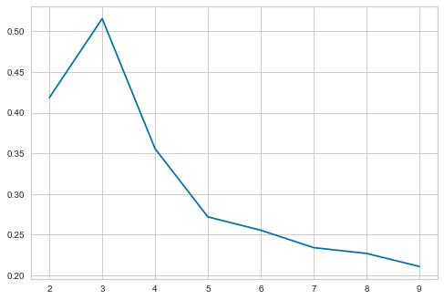

```python
sil_score = []
cluster_list = list(range(2, 10))
for n_clusters in cluster_list:
    clusterer = KMeans(n_clusters=n_clusters)
    preds = clusterer.fit_predict((dataScaled))
    # centers = clusterer.cluster_centers_
    score = silhouette_score(dataScaled, preds)
    sil_score.append(score)
    print("For n_clusters = {}, the silhouette score is {})".format(n_clusters, score))

plt.plot(cluster_list, sil_score)
plt.show()
```

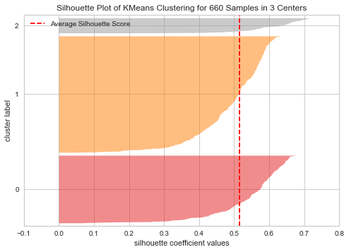

```python
# finding optimal no. of clusters with silhouette coefficients
visualizer = SilhouetteVisualizer(KMeans(3, random_state=1))
visualizer.fit(dataScaled)
visualizer.show();
```

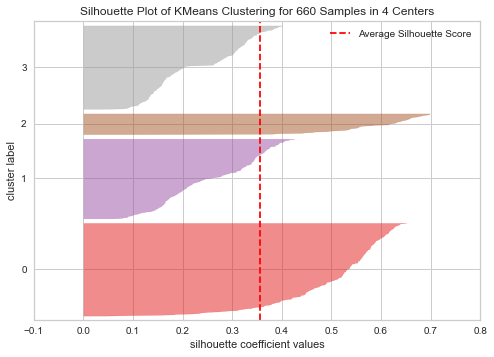

```python
# finding optimal no. of clusters with silhouette coefficients
visualizer = SilhouetteVisualizer(KMeans(4, random_state=1))
visualizer.fit(dataScaled)
visualizer.show();
```

We notice that Silhouette score is highest when number of clusters is 3 compared to 2 or 4 clusters. Hence appropriate number of clusters in this case would be 3.

```python
# let's take 3 as number of clusters
kmeans = KMeans(n_clusters=3, random_state=0)
kmeans.fit(dataScaled)
```

```
KMeans(n_clusters=3, random_state=0)
```

```python
# create a Dataframe from original data and delete the Sl_No and Customer Key which are not necessary.
df_km = data_bkp.drop(['Sl_No', 'Customer Key'], axis=1)
```

```python
# Mark the rows in original data and scaled data with the cluster labels
df_km['km_group'] = kmeans.labels_
dataScaled['km_group'] = kmeans.labels_
```

```python
df_km.sample(5)
```

|  | Avg_Credit_Limit | Total_Credit_Cards | Total_visits_bank | Total_visits_online | Total_calls_made | km_group |
| --- | --- | --- | --- | --- | --- | --- |
| 584 | 34000 | 6 | 4 | 1 | 3 | 0 |
| 299 | 9000 | 6 | 5 | 2 | 3 | 0 |
| 592 | 54000 | 5 | 4 | 2 | 1 | 0 |
| 101 | 11000 | 1 | 1 | 5 | 9 | 1 |
| 485 | 58000 | 7 | 3 | 2 | 1 | 0 |

```python
# Group by clusters and see summary statistics
df_km.groupby(['km_group']).agg(['median', 'max', 'min', 'count'])
```

| km_group | Avg_Credit_Limit median | Avg_Credit_Limit max | Avg_Credit_Limit min | Avg_Credit_Limit count | Total_Credit_Cards median | Total_Credit_Cards max | Total_Credit_Cards min | Total_Credit_Cards count | Total_visits_bank median | Total_visits_bank max | Total_visits_bank min | Total_visits_bank count | Total_visits_online median | Total_visits_online max | Total_visits_online min | Total_visits_online count | Total_calls_made median | Total_calls_made max | Total_calls_made min | Total_calls_made count |
| --- | --- | --- | --- | --- | --- | --- | --- | --- | --- | --- | --- | --- | --- | --- | --- | --- | --- | --- | --- | --- |
| 0 | 31000 | 100000 | 5000 | 386 | 6 | 7 | 2 | 386 | 3 | 5 | 1 | 386 | 1 | 3 | 0 | 386 | 2 | 4 | 0 | 386 |
| 1 | 12000 | 50000 | 3000 | 224 | 2 | 4 | 1 | 224 | 1 | 2 | 0 | 224 | 4 | 10 | 1 | 224 | 7 | 10 | 1 | 224 |
| 2 | 145500 | 200000 | 84000 | 50 | 9 | 10 | 5 | 50 | 1 | 1 | 0 | 50 | 11 | 15 | 6 | 50 | 1 | 3 | 0 | 50 |

> **Observations:**
> - Cluster 0: The largest group has 386 rows. Median average credit limit is 31K, median Total_Credit_Cards is 6. Prefer visiting bank rather than visiting online or making calls to bank.
> - Cluster 1: The 2nd largest group has 224 rows. This group has lowest Avg_Credit_Limit highest Total_calls_made and medium Total_visits_online.
> - Cluster 2: The smallest group has only 50 rows. However has highest avg credit limit and cards. This group also has high online visits and low visit to bank or calls made.

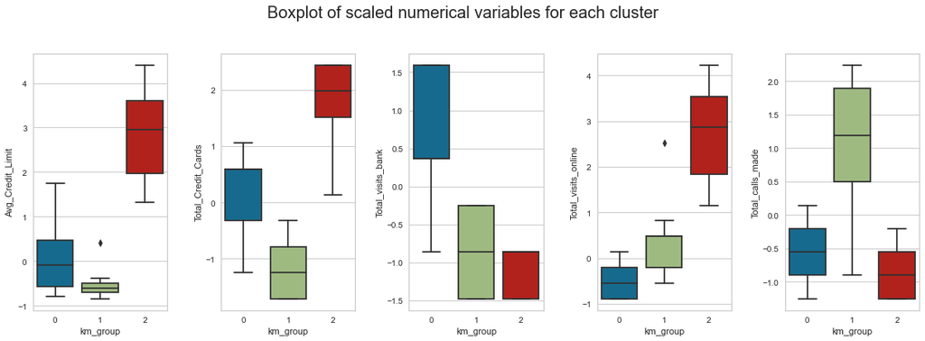

```python
fig, axes = plt.subplots(1, 5, figsize=(16, 6))
fig.suptitle("Boxplot of scaled numerical variables for each cluster", fontsize=20)
cols = df_km.columns
counter = 0
for ii in range(5):
    sns.boxplot(
        ax=axes[ii],
        y=dataScaled[cols[counter]],
        x=dataScaled["km_group"],
    )
    counter = counter + 1

fig.tight_layout(pad=2.0)
```

> **Observations:**
> - Avg_Credit_Limit: Ignoring the outliers, Cluster 0 captures the range around mean, while Cluster 1 and 2 captures the low and high end of the distribution.
> - Total_Credit_Cards: Similar to Avg_Credit_Limit, Cluster 0 captures the range around mean, while Cluster 1 and 2 captures the low and high end of the distribution.
> - Total_visits_bank: Cluster 0 stands out and captures the high end of the distribution but there is significant overlap between Cluster 1 and 2.
> - Total_visits_online: There is very little overlap between Cluster 0 and 1 but Cluster 1 has relatively higher values than 0. However Cluster 2 stands out and captures the high end of the distribution.
> - Total_calls_made: Cluster 1 has made the highes number of calls followed by Cluster 0 and 2. However there are significant overlaps between Cluster 0 and 2.

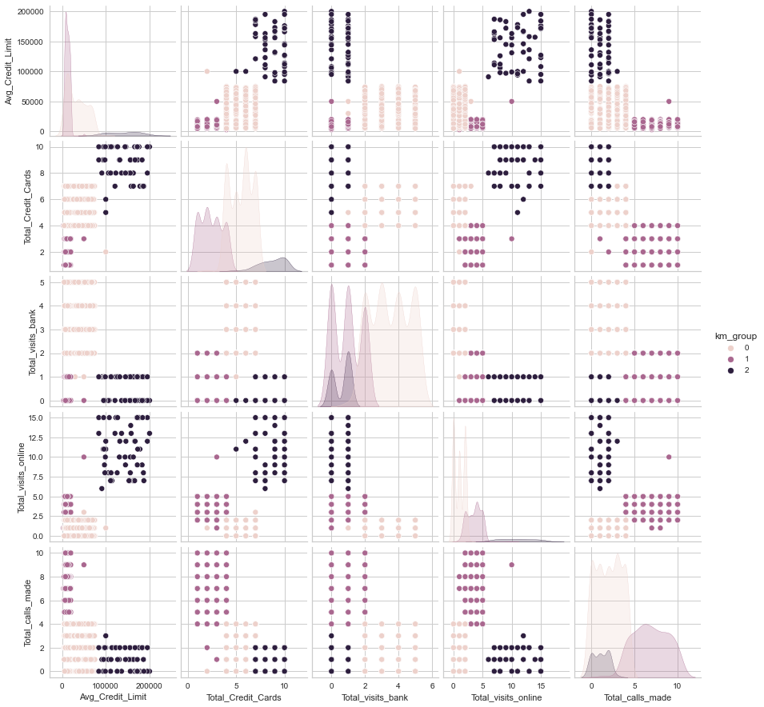

```python
# Checking the pairplot of the features with clusters
sns.pairplot(df_km, diag_kind="kde", hue='km_group');
```

The above pairplots show distribution of the data across three different clusters. Although there are overlaps in some cases (e.g. Total_visits_bank, Total_calls_made) but in most of the charts they occupy distinct segments of the domain space.

```python
# clean up the scaled data for Hierarchical Clustering
dataScaled.drop(['km_group'], axis=1, inplace=True)
```

## Hierarchical Clustering

Next, we will apply another clustering technique called, Hierarchical Clustering, on the scaled data to figure out the appropriate number of segments or clusters and visualize them.

```python
# to perform hierarchical clustering, compute cophenetic correlation, and create dendrograms
from sklearn.cluster import AgglomerativeClustering
from scipy.cluster.hierarchy import dendrogram, linkage, cophenet

# to compute distances
from scipy.spatial.distance import pdist
```

In order to derive the appropriate number of clusters we need draw dendrograms with different distance methods between data points and linkage methods between clusters. We would also like to measure Cophenetic correlation, which is a measure of how faithfully a dendrogram preserves the pairwise distances between the original unmodeled data points.

```python
# list of distance metrics
distance_metrics = ["euclidean", "chebyshev", "mahalanobis", "cityblock"]

# list of linkage methods
linkage_methods = ["single", "complete", "average", "weighted"]

high_cophenet_corr = 0
high_dm_lm = [0, 0]

for dm in distance_metrics:
    for lm in linkage_methods:
        Z = linkage(dataScaled, metric=dm, method=lm)
        c, coph_dists = cophenet(Z, pdist(dataScaled))
        print(
            "Cophenetic correlation for {} distance and {} linkage is {}.".format(
                dm.capitalize(), lm, c
            )
        )
        if high_cophenet_corr < c:
            high_cophenet_corr = c
            high_dm_lm[0] = dm
            high_dm_lm[1] = lm
```

```
Cophenetic correlation for Euclidean distance and single linkage is 0.7391220243806552.
Cophenetic correlation for Euclidean distance and complete linkage is 0.8599730607972423.
Cophenetic correlation for Euclidean distance and average linkage is 0.8977080867389372.
Cophenetic correlation for Euclidean distance and weighted linkage is 0.8861746814895477.
Cophenetic correlation for Chebyshev distance and single linkage is 0.7382354769296767.
Cophenetic correlation for Chebyshev distance and complete linkage is 0.8533474836336782.
Cophenetic correlation for Chebyshev distance and average linkage is 0.8974159511838106.
Cophenetic correlation for Chebyshev distance and weighted linkage is 0.8913624010768603.
Cophenetic correlation for Mahalanobis distance and single linkage is 0.7058064784553605.
Cophenetic correlation for Mahalanobis distance and complete linkage is 0.6663534463875359.
Cophenetic correlation for Mahalanobis distance and average linkage is 0.8326994115042136.
Cophenetic correlation for Mahalanobis distance and weighted linkage is 0.7805990615142517.
Cophenetic correlation for Cityblock distance and single linkage is 0.7252379350252723.
Cophenetic correlation for Cityblock distance and complete linkage is 0.8731477899179829.
Cophenetic correlation for Cityblock distance and average linkage is 0.896329431104133.
Cophenetic correlation for Cityblock distance and weighted linkage is 0.8825520731498188.
```

```python
# printing the combination of distance metric and linkage method with the highest cophenetic correlation
print(
    "Highest cophenetic correlation is {}, which is obtained with {} distance and {} linkage.".format(
        high_cophenet_corr, high_dm_lm[0].capitalize(), high_dm_lm[1]
    )
)
```

```
Highest cophenetic correlation is 0.8977080867389372, which is obtained with Euclidean distance and average linkage.
```

**Let's explore different linkage methods with Euclidean distance only.**

```
CPU times: user 5.23 s, sys: 236 ms, total: 5.47 s
Wall time: 4.32 s
```

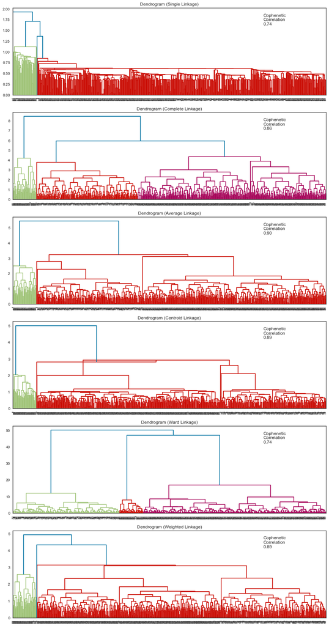

```python
%%time
sns.set_style("white")
# list of linkage methods
linkage_methods = ["single", "complete", "average", "centroid", "ward", "weighted"]

# lists to save results of cophenetic correlation calculation
compare_cols = ["Linkage", "Cophenetic Coefficient"]
compare = []

# to create a subplot image
fig, axs = plt.subplots(len(linkage_methods), 1, figsize=(15, 30))

# We will enumerate through the list of linkage methods above
# For each linkage method, we will plot the dendrogram and calculate the cophenetic correlation
for i, method in enumerate(linkage_methods):
    Z = linkage(dataScaled, metric="euclidean", method=method)

    dendrogram(Z, ax=axs[i])
    axs[i].set_title(f"Dendrogram ({method.capitalize()} Linkage)")
    #axs[i].set_facecolor('white')
    coph_corr, coph_dist = cophenet(Z, pdist(dataScaled))
    axs[i].annotate(
        f"Cophenetic\nCorrelation\n{coph_corr:0.2f}",
        (0.80, 0.80),
        xycoords="axes fraction",
    )

    compare.append([method, coph_corr])
```

```python
# let's create a dataframe to compare cophenetic correlations for each linkage method
df_cc = pd.DataFrame(compare, columns=compare_cols)
df_cc.sort_values(by='Cophenetic Coefficient', ascending=False)
```

|  | Linkage | Cophenetic Coefficient |
| --- | --- | --- |
| 2 | average | 0.897708 |
| 3 | centroid | 0.893939 |
| 5 | weighted | 0.886175 |
| 1 | complete | 0.859973 |
| 4 | ward | 0.741516 |
| 0 | single | 0.739122 |

Although the Euclidean distance and average linkage gives the highest Cophenetic Coefficient but the Ward linkage shows clear seperation of 3 clusters and has longest Dendrogramic distance on the Y axis. So the appropriate number of clusters would be 3 in this case with Euclidean distance and Ward linkage.

```python
HCmodel = AgglomerativeClustering(n_clusters=3, affinity="euclidean", linkage="ward")
HCmodel.fit(dataScaled)
```

```
AgglomerativeClustering(n_clusters=3)
```

```python
df_hc = data_bkp.drop(['Sl_No', 'Customer Key'], axis=1)
```

```python
# Mark the rows in original data and scaled data with the cluster labels
df_hc['hc_group'] = HCmodel.labels_
dataScaled['hc_group'] = HCmodel.labels_
```

```python
df_hc.groupby(['hc_group']).agg(['median', 'max', 'min', 'count'])
```

| hc_group | Avg_Credit_Limit median | Avg_Credit_Limit max | Avg_Credit_Limit min | Avg_Credit_Limit count | Total_Credit_Cards median | Total_Credit_Cards max | Total_Credit_Cards min | Total_Credit_Cards count | Total_visits_bank median | Total_visits_bank max | Total_visits_bank min | Total_visits_bank count | Total_visits_online median | Total_visits_online max | Total_visits_online min | Total_visits_online count | Total_calls_made median | Total_calls_made max | Total_calls_made min | Total_calls_made count |
| --- | --- | --- | --- | --- | --- | --- | --- | --- | --- | --- | --- | --- | --- | --- | --- | --- | --- | --- | --- | --- |
| 0 | 31000 | 100000 | 5000 | 385 | 6 | 7 | 2 | 385 | 3 | 5 | 1 | 385 | 1 | 3 | 0 | 385 | 2 | 4 | 0 | 385 |
| 1 | 12000 | 50000 | 3000 | 225 | 2 | 5 | 1 | 225 | 1 | 2 | 0 | 225 | 4 | 10 | 1 | 225 | 7 | 10 | 1 | 225 |
| 2 | 145500 | 200000 | 84000 | 50 | 9 | 10 | 5 | 50 | 1 | 1 | 0 | 50 | 11 | 15 | 6 | 50 | 1 | 3 | 0 | 50 |

Below observations are very similar to K-means.

> - Cluster 0: The largest group has 385 rows. Median average credit limit is 31K, median Total_Credit_Cards is 6. Prefer visiting bank rather than visiting online or making calls to bank.
> - Cluster 1: The 2nd largest group has 225 rows. This group has lowest Avg_Credit_Limit highest Total_calls_made and medium Total_visits_online.
> - Cluster 2: The smallest group has only 50 rows. However has highest avg credit limit and cards. This group also has high online visits and low visit to bank or calls made.

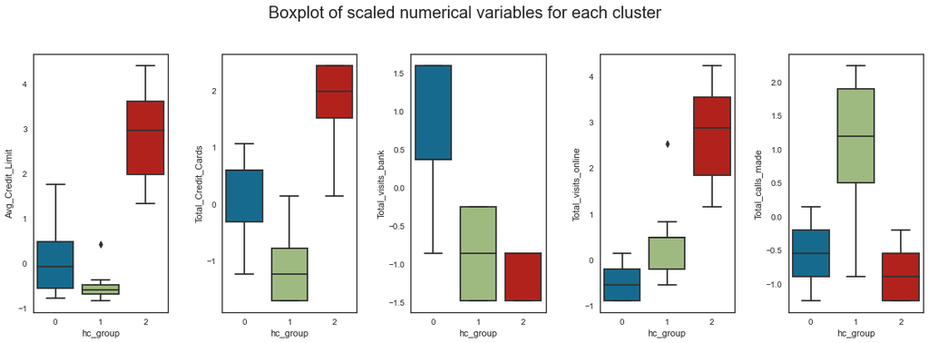

```python
fig, axes = plt.subplots(1, 5, figsize=(16, 6))
fig.suptitle("Boxplot of scaled numerical variables for each cluster", fontsize=20)
cols = df_hc.columns
counter = 0
for ii in range(5):
    sns.boxplot(
        ax=axes[ii],
        y=dataScaled[cols[counter]],
        x=dataScaled["hc_group"],
    )
    counter = counter + 1

fig.tight_layout(pad=2.0)
```

> **Observations:**
> - Avg_Credit_Limit: Ignoring the outliers, Cluster 0 captures the range around mean, while Cluster 1 and 2 captures the low and high end of the distribution.
> - Total_Credit_Cards: Similar to Avg_Credit_Limit, Cluster 0 captures the range around mean, while Cluster 1 and 2 captures the low and high end of the distribution.
> - Total_visits_bank: Cluster 0 stands out and captures the high end of the distribution but there is significant overlap between Cluster 1 and 2.
> - Total_visits_online: There is very little overlap between Cluster 0 and 1 but Cluster 1 has relatively higher values than 0. However Cluster 2 stands out and captures the high end of the distribution.
> - Total_calls_made: Cluster 1 has made the highes number of calls followed by Cluster 0 and 2. However there are significant overlaps between Cluster 0 and 2.

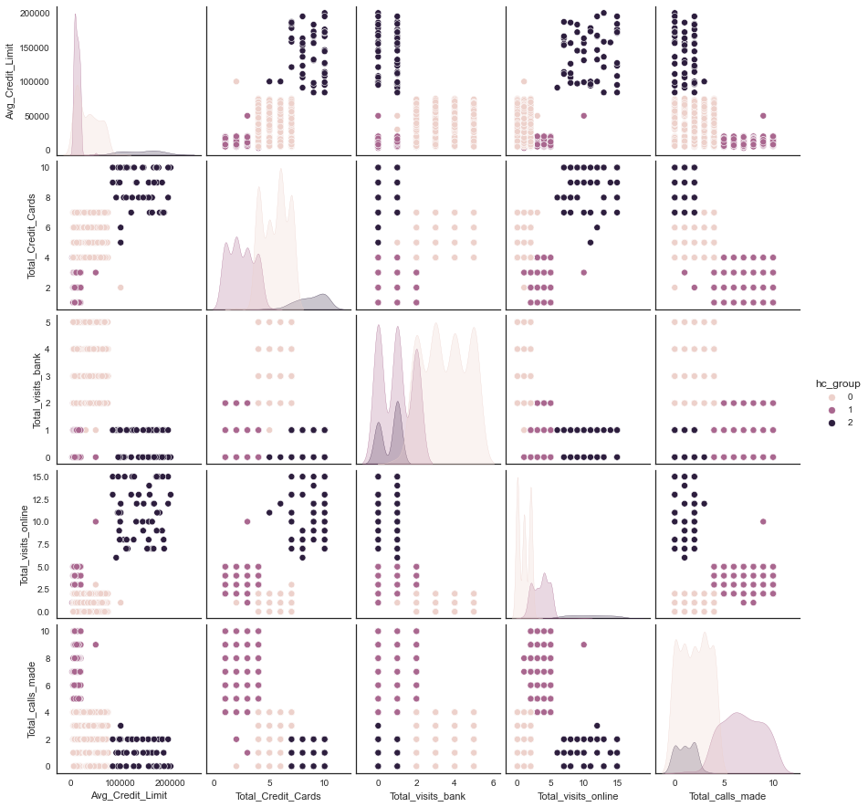

```python
# Checking the pairplot of all the relations with respect to the Hierarchical Clustering segmentation
sns.pairplot(df_hc, diag_kind="kde", hue='hc_group');
```

Similar to K-means clusters, the above pairplots show distribution of the data across three different clusters with respect to Hierarchical clustering. Although there are overlaps in some cases (e.g. Total_visits_bank, Total_calls_made) but in most of the charts they occupy distinct segments of the domain space.

```python
# Remove the hc_group column from the Scaled dataset, so that we can reuse the dataset for further analysis
dataScaled.drop(['hc_group'], axis=1, inplace=True)
```

## Visual Analysis with Dimentionality Reduction

Although, there are only handful of columns and dimentionality reduction may not be necessary but it will be interesting to see how PCA and t-SNE shows the clusters of the data in lower dimentions.

### Applying Principal Component Analysis (PCA)

```python
# to perform PCA
from sklearn.decomposition import PCA
```

```python
pca = PCA(n_components=2)
pca_data = pca.fit_transform(dataScaled)
```

```python
pca_df = pd.DataFrame(
    data=pca_data, columns=["Principal Component 1", "Principal Component 2"]
)
pca_df.tail()
```

|  | Principal Component 1 | Principal Component 2 |
| --- | --- | --- |
| 655 | 3.038539 | 2.666249 |
| 656 | 2.567247 | 3.341750 |
| 657 | 2.851444 | 2.983081 |
| 658 | 4.178258 | 4.582930 |
| 659 | 3.160426 | 4.351019 |

```python
print(
    "Explained variance per principal component: {}".format(
        pca.explained_variance_ratio_
    )
)
```

```
Explained variance per principal component: [0.45736578 0.37426483]
```

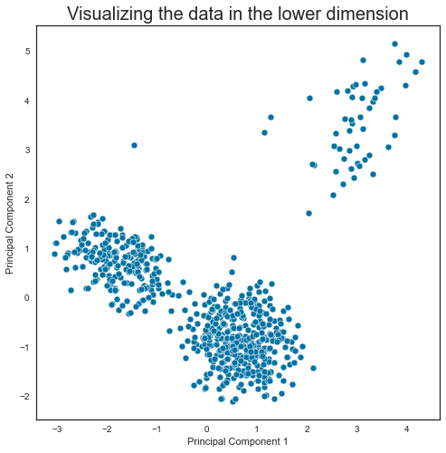

```python
plt.figure(figsize=(8, 8))
sns.scatterplot(data=pca_df, x="Principal Component 1", y="Principal Component 2")
plt.title("Visualizing the data in the lower dimension", fontsize=20)
plt.show()
```

> **Observations:**
> - With only two features PCA was able to capture 83% of the variance in the data.
> - PCA also shows the data in three clusters in lower dimentions.
> - This further corroborates our findings with K-means and Hierarchical Clustering.

### Applying t-distributed Stochastic Neighbor Embedding (t-SNE)

```python
# to perform t-SNE
from sklearn.manifold import TSNE

tsne = TSNE(n_components=2, random_state=1)
tsne_data = tsne.fit_transform(dataScaled)
```

```python
tsne_df = pd.DataFrame(data=tsne_data, columns=["Component 1", "Component 2"])
tsne_df.tail()
```

|  | Component 1 | Component 2 |
| --- | --- | --- |
| 655 | -50.595222 | 0.696939 |
| 656 | -52.565746 | 0.982240 |
| 657 | -49.209915 | 2.728788 |
| 658 | -53.159721 | 4.923207 |
| 659 | -51.338978 | 4.346826 |

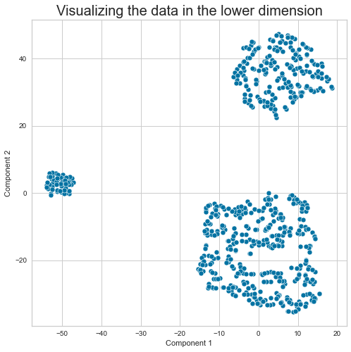

```python
plt.figure(figsize=(8, 8))
sns.set_style("whitegrid")
sns.scatterplot(data=tsne_df, x="Component 1", y="Component 2")
plt.title("Visualizing the data in the lower dimension", fontsize=20)
plt.show()
```

> **Observations:**
> - With t-SNE, we also see that dataset is segmented in three clusters similar to PCA, K-means and Hierarchical Clustering.

Let's check how the segmentation changes with different perplexity parameters. Also findout the optimized perplexity parameter.

```
Visualizing the lower dimensional representation of data for different values of perplexity
```

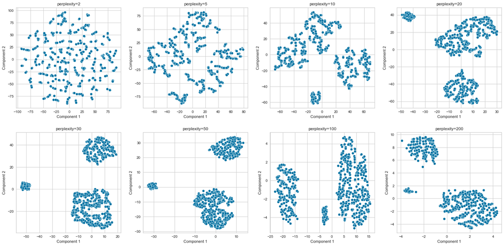

```python
perplexity = [2, 5, 10, 20, 30, 50, 100, 200]

plt.figure(figsize=(20, 10))
print(
    "Visualizing the lower dimensional representation of data for different values of perplexity"
)

for i in range(len(perplexity)):
    tsne = TSNE(n_components=2, perplexity=perplexity[i], n_jobs=-2, random_state=1)
    # n_jobs specifies the number of parallel jobs to run
    # -2 means using all processors except one
    X_red = tsne.fit_transform(dataScaled)

    red_data_df = pd.DataFrame(data=X_red, columns=["Component 1", "Component 2"])

    plt.subplot(2, int(len(perplexity) / 2), i + 1)

    plt.title("perplexity=" + str(perplexity[i]))
    sns.scatterplot(data=red_data_df, x="Component 1", y="Component 2"),
    plt.tight_layout(pad=2)
```

Based on the above charts, it seems the optimized perplexity parameter would be 50 in this case.

## Conclusions

After analysis of the dataset of AllLife Bank's credit card profile data with K-means and Hierarchical Clustering we can conclude the following insights:

- **Cluster 0**:
  - This cluster contains medium Avg_Credit_Limit customers, with a median Avg_Credit_Limit of approximately 31K.
  - Also these customers contains medium number of credit cards with median value of 6.
  - For sevicing needs these customers mostly prefer to visit bank rather than going online or calling customer service.
  - This is the largest segment/group.
- **Cluster 1**:
  - This cluster contains low Avg_Credit_Limit customers, with a median Avg_Credit_Limit of approximately 12K.
  - Also these customers contains minimum number of credit cards with median value of 2.
  - For sevicing needs these customers mostly prefer to call customer service phone line. However some customers use online and visit bank.
  - This is the 2nd largest segment/group.
- **Cluster 2**:
  - This cluster contains high Avg_Credit_Limit customers, with a median Avg_Credit_Limit of approximately 145K.
  - Also these customers contains highest number of credit cards with median value of 9.
  - For sevicing needs these customers prefers to visit online rather than visiting bank or calling customer service.
  - Although this the the smallest group but it is the premium segment.

## Business Recommendations

- Cluster 2, however small, consists of premium customers, so focused highend financial product marketing campaigns can be targeted to these customers which require higher credit limit and income. This group also prefers to use mostly online banking hence offers and campaigns need to be targeted online on mobile and social media platforms rather than direct or mail marketing. Bank needs to provide all kinds of self servicing facilities online in order to retain these customers and improve customer satisfaction.
- Cluster 0 consists of mid range customers. This group can be targeted with more credit cards offers, balance transfer from other banks etc. to move them to premium segment. One interesting obeservation about this group is that they prefer to visit bank for servicing needs rather than using online banking. Since it is the larget segment, customer service at the branches need to be improved and new product offering can be marketed by the branches. However, in the long run, bank needs to come up with plans to move these customers to online banking to reduce the operational and support costs.
- Cluster 1 consists of economy customers with lowest number of credit cards and avg credit limit. This is the second largest segment and for servicing needs they prefer calling customer service although many customers go to online as well. Focused marketing campaign with low range credit card offers can be targeted either by mail marketing or by customer service channels. Trained customer service agents needs to be employed by the call centers to improve the customer experience and retention. Again bank needs to push these customers to online self servicing channels to reduce operational costs.